# Homework 2

PSTAT 131/231

```r
library(ggplot2)
library(tidyverse)
library(tidymodels)
library(corrplot)
library(ggthemes)
tidymodels_prefer()
```

## Linear Regression

The age of an abalone is typically determined by cutting the shell open and counting the number of rings with a microscope. The purpose of this data set is to determine whether abalone age (**number of rings + 1.5**) can be accurately predicted using other, easier-to-obtain information about the abalone.

The full abalone data set is located in the `\data` subdirectory. Read it into *R* using `read_csv()`. Take a moment to read through the codebook (`abalone_codebook.txt`) and familiarize yourself with the variable definitions.

Make sure you load the `tidyverse` and `tidymodels`!

### Question 1

```r
data1 <- read.csv("/Users/lhz/Desktop/---/PSTAT-131-HAOZHE-LI-HW-1/abalone.csv")
View(data1)
attach(data1)
input <- data1[,c('type','longest_shell','diameter','height','whole_weight','shucked_weight','viscera_weight','shell_weight','rings')]
data2 <- data.frame(type = type, longest_shell=longest_shell, diameter=diameter, height=height, whole_weight=whole_weight, shucked_weight=shucked_weight,viscera_weight=viscera_weight,shell_weight=shell_weight,rings=rings,age=rings+1.5)
View(data2)
attach(data2)
```

Your goal is to predict abalone age, which is calculated as the number of rings plus 1.5. Notice there currently is no `age` variable in the data set. Add `age` to the data set.

Assess and describe the distribution of `age`.

```r
class(data1$age)
```

```
## [1] "NULL"
```

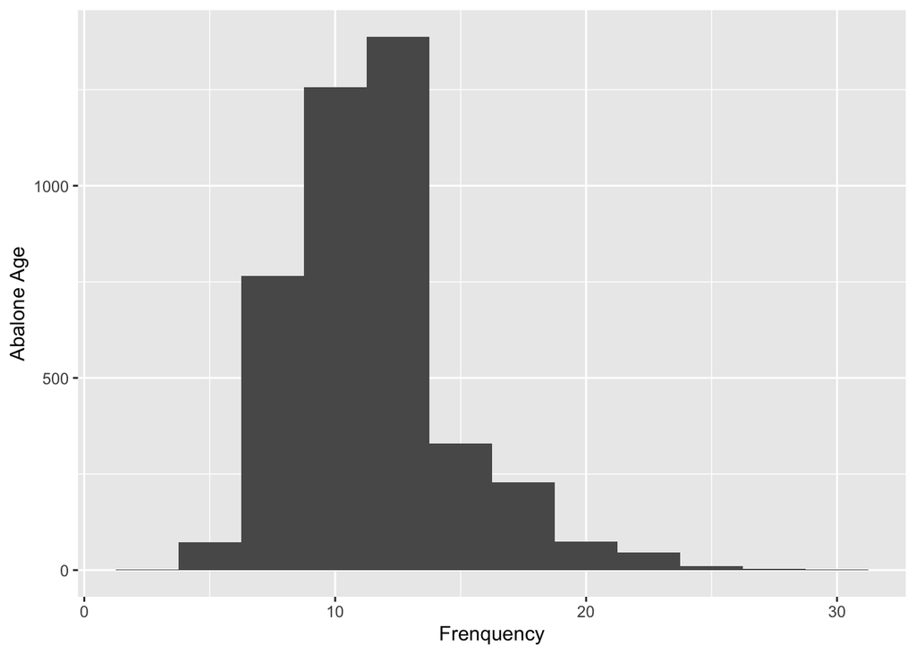

```r
p <- ggplot(data = data2, aes(x=age)) + geom_histogram(binwidth = 2.5) +xlab("Frenquency")+ylab("Abalone Age")
p
```

Most of the abalone age is around 10 years and barely abalone which age is over 20 years and also there are barely abalone are below 5 years

### Question 2

Split the abalone data into a training set and a testing set. Use stratified sampling. You should decide on appropriate percentages for splitting the data.

*Remember that you’ll need to set a seed at the beginning of the document to reproduce your results.*

```r
set.seed(3435)

abalone_split <- initial_split(data2, prop = 0.80)
abalone_train <- training(abalone_split)
abalone_test <- testing(abalone_split)
```

### Question 3

Using the **training** data, create a recipe predicting the outcome variable, `age`, with all other predictor variables. Note that you should not include `rings` to predict `age`. Explain why you shouldn’t use `rings` to predict `age`.

Steps for your recipe:

1. dummy code any categorical predictors

```r
abalone_recipe <- recipe(age ~ type + longest_shell + diameter + height + whole_weight + shucked_weight + viscera_weight + shell_weight, data = abalone_train) %>%
  step_dummy(all_nominal_predictors())
```

Because we already set the relationship between rings and age which is age=rings+1.5 so we dont need to predict it

2. create interactions between
   - `type` and `shucked_weight`,
   - `longest_shell` and `diameter`,
   - `shucked_weight` and `shell_weight`
3. center all predictors, and
4. scale all predictors.

You’ll need to investigate the `tidymodels` documentation to find the appropriate step functions to use.

```r
int_mod_1 <- abalone_recipe  %>%
    step_interact(terms = ~ type:shucked_weight)
int_mod_1 <- abalone_recipe  %>%
    step_interact(terms = ~ longest_shell:diameter)
int_mod_1 <- abalone_recipe  %>%
    step_interact(terms = ~ shucked_weight:shell_weight)
abalone_train_scale <- abalone_train %>% mutate(across(where(is.numeric),scale))
abalone_train_scale2 <- subset(abalone_train_scale, select=-c(rings))
abalone_train_scale_r <- recipe(age ~ ., data = abalone_train_scale2) %>%
  step_dummy(all_nominal_predictors())
abalone_train_scale2
```

[output not shown]

[output cut: 6669 more lines]

### Question 4

Create and store a linear regression object using the `"lm"` engine.

```r
lm_model <- linear_reg() %>%
  set_engine("lm")
```

### Question 5

Now:

1. set up an empty workflow,
2. add the model you created in Question 4, and
3. add the recipe that you created in Question 3.

```r
lm_wflow <- workflow() %>%
  add_model(lm_model) %>%
  add_recipe(abalone_train_scale_r)

lm_fit <- fit(lm_wflow, abalone_train)
```

```r
lm_fit %>%
  extract_fit_parsnip() %>%
  tidy()
```

```
## # A tibble: 10 × 5
##    term            estimate std.error statistic  p.value
##    <chr>              <dbl>     <dbl>     <dbl>    <dbl>
##  1 (Intercept)      5.40       0.329    16.4    2.93e-58
##  2 longest_shell   -1.73       2.11     -0.819  4.13e- 1
##  3 diameter        13.3        2.59      5.11   3.40e- 7
##  4 height           9.19       1.63      5.64   1.80e- 8
##  5 whole_weight     8.35       0.803    10.4    6.39e-25
##  6 shucked_weight -19.0        0.910   -20.9    6.56e-91
##  7 viscera_weight -10.3        1.45     -7.13   1.20e-12
##  8 shell_weight     9.41       1.26      7.48   9.43e-14
##  9 type_I          -0.842      0.115    -7.32   3.10e-13
## 10 type_M           0.00882    0.0940    0.0938 9.25e- 1
```

### Question 6

Use your `fit()` object to predict the age of a hypothetical female abalone with longest_shell = 0.50, diameter = 0.10, height = 0.30, whole_weight = 4, shucked_weight = 1, viscera_weight = 2, shell_weight = 1.

```r
variable <- data.frame(type='F', longest_shell = 0.50, diameter = 0.10, height = 0.30, whole_weight = 4, shucked_weight = 1, viscera_weight = 2, shell_weight = 1)
predict(lm_fit, new_data = variable)
```

```
## # A tibble: 1 × 1
##   .pred
##   <dbl>
## 1  11.8
```

### Question 7

Now you want to assess your model’s performance. To do this, use the `yardstick` package:

1. Create a metric set that includes *R<sup>2</sup>*, RMSE (root mean squared error), and MAE (mean absolute error).
2. Use `predict()` and `bind_cols()` to create a tibble of your model’s predicted values from the **training data** along with the actual observed ages (these are needed to assess your model’s performance).
3. Finally, apply your metric set to the tibble, report the results, and interpret the *R<sup>2</sup>* value.

```r
library(dplyr)
library(yardstick)
multi_metric <- metric_set(rsq, rmse, mae)
prediction<-predict(lm_fit, new_data = abalone_train)
prediction_table <- bind_cols(abalone_train$age, prediction, id=NULL)
colnames(prediction_table)[1] = "Age of the Abalone"
colnames(prediction_table)[2] = "Estimate"
prediction_table
```

```
## # A tibble: 3,341 × 2
##    `Age of the Abalone` Estimate
##                   <dbl>    <dbl>
##  1                  9.5    12.0
##  2                  9.5    10.6
##  3                 13.5    13.2
##  4                 10.5    11.3
##  5                 19.5    13.7
##  6                 10.5    12.4
##  7                 12.5    11.9
##  8                  8.5     7.93
##  9                  8.5    10.2
## 10                  6.5     9.28
## # … with 3,331 more rows
```

```r
abalone_train %>%
  multi_metric(truth=prediction_table$`Age of the Abalone`, estimate=prediction_table$Estimate)
```

```
## # A tibble: 3 × 3
##   .metric .estimator .estimate
##   <chr>   <chr>          <dbl>
## 1 rsq     standard       0.533
## 2 rmse    standard       2.21
## 3 mae     standard       1.59
```